# INTRODUCCION

El objetivo del reporte no es analizar las diferencias de las valuaciones de AGIP respecto a los precios de mercado en valores absolutos, sino analizar las diferencias en términos relativos respecto a los barrios.

Por ejemplo, si un barrio tiene un precio promedio de mercado dos veces superior a la media, lo "correcto" seria esperar que su valuación fiscal sea del doble respecto a la media de las valuaciones promedio. Si se encuentra por debajo, esto muestra la posiblidad de elevar la tasación fiscal a efectos de acompañar las diferencias en precios de los barrios.

Para realizar este analisis se trabajó con la tabla de ABL (valuaciones código 40002) de AGIP y las valuaciones de mercado de properati. Se compatiblizaron los barrios de ambas tablas, de agruparon las propiedades por barrios, y se calcularon diversos indicadores.

# INDICE DE VALUACION AGIP - PROPERATI

## Analisis BaseABL

La base ABL contiene 1409185 registros y 12 columnas

```
<class 'pandas.core.frame.DataFrame'>
RangeIndex: 1409185 entries, 0 to 1409184
Data columns (total 12 columns):
 #   Column           Non-Null Count    Dtype
---  ------           --------------    -----
 0   nro_partida      1409185 non-null  int64
 1   valuacion_total  1409185 non-null  float64
 2   anio_vigencia    1409185 non-null  int64
 3   cod_valuacion    1409185 non-null  int64
 4   barrios          1360988 non-null  object
 5   cod_manzana      1409185 non-null  object
 6   cod_parcela      1409185 non-null  object
 7   cod_seccion      1409185 non-null  int64
 8   Id_manzana       1360988 non-null  object
 9   Id_parcela       1360988 non-null  object
 10  Id_seccion       1360988 non-null  float64
 11  barrios.1        1360988 non-null  object
dtypes: float64(2), int64(4), object(6)
memory usage: 129.0+ MB
```

#### Valores extremos

La posible presencia de valuaciones extremas distorsionan el analisis general. Estas distorsiones requieren una analisis particular, el cual no se desarrolla en este notebook.  
Creamos las columnas para el percentil 5 y el 95. Los que están fuera de ese rango, se marcan como `del` y se eliminan.

Luego de la eliminación de los valores extremos, la base ABL queda con 1224506 registros y 15 columnas

[output not shown]

| barrios | count | mean | std | min | 25% | 50% | 75% | max | Coef_Var | Rango_medio |
| --- | --- | --- | --- | --- | --- | --- | --- | --- | --- | --- |
| BOCA | 10131.00 | 562958.29 | 371115.31 | 43898.83 | 335998.75 | 461220.99 | 708336.27 | 1948233.05 | 0.66 | 3.38 |
| CONSTITUCION | 13340.00 | 594348.68 | 333582.20 | 151473.44 | 374942.55 | 508252.05 | 720054.80 | 2211184.29 | 0.56 | 3.47 |
| BALVANERA | 59894.00 | 641106.39 | 369792.73 | 78407.96 | 385407.72 | 558249.10 | 818905.46 | 2083100.86 | 0.58 | 3.13 |
| SAN NICOLAS | 42495.00 | 650182.31 | 557594.32 | 51895.67 | 266748.16 | 487034.95 | 828747.71 | 3185988.31 | 0.86 | 4.82 |
| SAN TELMO | 9301.00 | 669971.82 | 376724.27 | 135580.86 | 410473.89 | 583959.73 | 809274.41 | 2518748.45 | 0.56 | 3.56 |
| ALMAGRO | 58694.00 | 699530.37 | 386833.76 | 39063.21 | 425523.35 | 626712.97 | 896811.64 | 2067947.00 | 0.55 | 2.90 |
| MONSERRAT | 24102.00 | 705268.91 | 559251.86 | 63519.83 | 317446.22 | 560108.78 | 913038.89 | 3285334.67 | 0.79 | 4.57 |
| SAN CRISTOBAL | 17528.00 | 708074.02 | 443059.54 | 23948.20 | 420760.04 | 610263.96 | 876095.58 | 2646967.62 | 0.63 | 3.70 |
| VILLA LUGANO | 16693.00 | 719104.29 | 538057.22 | 201387.78 | 300985.99 | 548009.09 | 923281.43 | 2575392.58 | 0.75 | 3.30 |
| BARRACAS | 19745.00 | 726469.17 | 512573.39 | 29991.83 | 382489.65 | 604958.52 | 926117.74 | 2725613.67 | 0.71 | 3.71 |
| VILLA CRESPO | 37801.00 | 799132.94 | 481422.64 | 86162.24 | 480452.27 | 679812.99 | 987362.74 | 2855660.46 | 0.60 | 3.47 |
| BOEDO | 16502.00 | 807730.42 | 562421.64 | 86495.34 | 435486.59 | 642814.53 | 988448.73 | 3142208.15 | 0.70 | 3.78 |
| PARQUE CHACABUCO | 20218.00 | 811518.36 | 536601.56 | 32808.30 | 441090.99 | 674179.20 | 1041028.14 | 2764013.76 | 0.66 | 3.37 |
| FLORES | 50673.00 | 813099.99 | 540760.40 | 31916.79 | 452696.08 | 687354.13 | 1040144.56 | 2916879.67 | 0.67 | 3.55 |
| PARQUE PATRICIOS | 11200.00 | 824851.17 | 671993.84 | 45648.37 | 426473.42 | 594208.51 | 968750.77 | 3758095.81 | 0.81 | 4.50 |
| VILLA GRAL. MITRE | 11105.00 | 825685.13 | 602675.05 | 197780.92 | 445743.78 | 619870.20 | 954881.77 | 3478850.58 | 0.73 | 3.97 |
| NUEVA POMPEYA | 10001.00 | 841405.46 | 599086.37 | 153734.88 | 422637.17 | 617022.92 | 1103860.12 | 2934558.70 | 0.71 | 3.30 |
| CABALLITO | 84354.00 | 847077.78 | 549519.34 | 25205.41 | 460147.20 | 733427.57 | 1132704.55 | 2709115.60 | 0.65 | 3.17 |
| COLEGIALES | 25071.00 | 853654.72 | 600760.03 | 18875.26 | 462332.22 | 727136.10 | 1127074.45 | 3143647.00 | 0.70 | 3.66 |
| CHACARITA | 11206.00 | 891695.56 | 648304.90 | 112189.24 | 489943.55 | 718023.91 | 1046726.85 | 3849898.23 | 0.73 | 4.19 |
| VILLA SANTA RITA | 12222.00 | 905612.56 | 609428.28 | 95467.29 | 510718.49 | 723886.44 | 1092567.05 | 3495854.04 | 0.67 | 3.75 |
| VILLA PUEYRREDON | 14266.00 | 927097.65 | 620196.04 | 209573.56 | 514313.29 | 702772.74 | 1105403.19 | 3222510.73 | 0.67 | 3.25 |
| VELEZ SARSFIELD | 11459.00 | 932209.54 | 663589.51 | 136421.12 | 482563.93 | 693952.69 | 1136427.75 | 3374038.22 | 0.71 | 3.47 |
| AGRONOMIA | 4912.00 | 932942.00 | 646468.22 | 177278.90 | 478665.26 | 701936.92 | 1169176.20 | 3267945.87 | 0.69 | 3.31 |
| VILLA LURO | 12625.00 | 945058.03 | 680648.61 | 58814.07 | 513951.40 | 728893.32 | 1120898.11 | 3588595.06 | 0.72 | 3.73 |
| NUÑEZ | 27966.00 | 951925.76 | 687650.01 | 27169.58 | 518606.65 | 805797.16 | 1219053.59 | 3873426.74 | 0.72 | 4.04 |
| MONTE CASTRO | 12254.00 | 955672.57 | 647833.74 | 255781.98 | 513122.48 | 721352.32 | 1165126.45 | 3444435.90 | 0.68 | 3.34 |
| VILLA RIACHUELO | 3978.00 | 957206.70 | 649103.71 | 155303.43 | 473387.40 | 712002.84 | 1287333.90 | 3023261.27 | 0.68 | 3.00 |
| FLORESTA | 12240.00 | 959901.98 | 750844.80 | 236630.83 | 481326.68 | 687467.63 | 1114888.12 | 4104123.30 | 0.78 | 4.03 |
| LINIERS | 16179.00 | 961830.69 | 656273.11 | 144054.40 | 524346.48 | 732073.56 | 1184155.43 | 3436188.26 | 0.68 | 3.42 |
| VILLA DEL PARQUE | 22192.00 | 966131.51 | 704106.02 | 33778.92 | 503779.18 | 754648.44 | 1177701.68 | 3827705.30 | 0.73 | 3.93 |
| VILLA URQUIZA | 46398.00 | 974497.29 | 664509.32 | 42765.61 | 569684.86 | 796566.37 | 1202200.90 | 3666518.19 | 0.68 | 3.72 |
| VILLA SOLDATI | 5313.00 | 1025458.44 | 596795.15 | 311609.68 | 610412.17 | 836873.24 | 1225152.06 | 3161720.05 | 0.58 | 2.78 |
| PARQUE AVELLANEDA | 10837.00 | 1047788.04 | 751884.14 | 221690.60 | 494287.33 | 762769.33 | 1407531.63 | 3536850.65 | 0.72 | 3.16 |
| PATERNAL | 5566.00 | 1049128.91 | 812131.73 | 118254.10 | 503692.94 | 759974.81 | 1295544.84 | 4284552.69 | 0.77 | 3.97 |
| PALERMO | 140214.00 | 1080247.80 | 871905.02 | 28144.68 | 482166.31 | 874333.43 | 1463447.56 | 4456531.18 | 0.81 | 4.10 |
| COGHLAN | 8388.00 | 1109853.05 | 896830.09 | 54486.66 | 534386.46 | 829629.03 | 1352302.62 | 4535540.31 | 0.81 | 4.04 |
| SAAVEDRA | 19089.00 | 1132217.57 | 856389.65 | 55950.99 | 568530.40 | 854202.82 | 1423307.68 | 4129956.63 | 0.76 | 3.60 |
| MATADEROS | 18734.00 | 1137593.01 | 856675.02 | 177859.44 | 532563.51 | 806058.19 | 1498706.73 | 3976444.99 | 0.75 | 3.34 |
| VILLA REAL | 3941.00 | 1138265.53 | 720048.06 | 263401.55 | 572733.01 | 909157.04 | 1547273.95 | 3430542.36 | 0.63 | 2.78 |
| BELGRANO | 76294.00 | 1138897.17 | 975810.94 | 22225.47 | 396885.78 | 911661.71 | 1597210.63 | 4756107.11 | 0.86 | 4.16 |
| RETIRO | 31939.00 | 1142462.77 | 1159754.16 | 49445.62 | 300792.22 | 700266.62 | 1593120.85 | 5845317.24 | 1.02 | 5.07 |
| PARQUE CHAS | 6563.00 | 1152307.45 | 805943.46 | 234075.02 | 574466.40 | 832912.75 | 1504323.89 | 3772237.66 | 0.70 | 3.07 |
| RECOLETA | 98912.00 | 1176747.52 | 891725.03 | 33282.79 | 528855.61 | 945888.29 | 1680509.76 | 4082112.03 | 0.76 | 3.44 |
| VERSALLES | 4594.00 | 1182081.85 | 825097.59 | 181008.09 | 572328.72 | 884290.28 | 1601959.89 | 3854930.03 | 0.70 | 3.11 |
| VILLA ORTUZAR | 8333.00 | 1192266.64 | 1045851.08 | 40735.33 | 552209.41 | 821238.51 | 1438871.34 | 5409887.36 | 0.88 | 4.50 |
| VILLA DEVOTO | 25351.00 | 1192779.25 | 1003008.20 | 52781.58 | 531173.13 | 818483.05 | 1500946.56 | 4880262.22 | 0.84 | 4.05 |
| PUERTO MADERO | 13693.00 | 1498999.01 | 2228604.69 | 24270.79 | 176445.56 | 388238.19 | 2138809.94 | 9882418.86 | 1.49 | 6.58 |

### Indice de valuación AGIP

El índice de valuación AGIP computa las valuaciones medias de cada barrio, tomando como base el promedio de las valuaciones agragadas de CABA.

|  | barrios | valuacion_media_agip | index_agip |
| --- | --- | --- | --- |
| 40 | PUERTO MADERO | 1498999.01 | 160.75% |
| 37 | VILLA DEVOTO | 1192779.25 | 127.91% |
| 28 | VILLA ORTUZAR | 1192266.64 | 127.86% |
| 39 | VERSALLES | 1182081.85 | 126.76% |
| 44 | RECOLETA | 1176747.52 | 126.19% |
| 26 | PARQUE CHAS | 1152307.45 | 123.57% |
| 45 | RETIRO | 1142462.77 | 122.52% |
| 43 | BELGRANO | 1138897.17 | 122.13% |
| 8 | VILLA REAL | 1138265.53 | 122.07% |
| 17 | MATADEROS | 1137593.01 | 121.99% |
| 20 | SAAVEDRA | 1132217.57 | 121.42% |
| 21 | COGHLAN | 1109853.05 | 119.02% |
| 33 | PALERMO | 1080247.80 | 115.84% |
| 1 | PATERNAL | 1049128.91 | 112.51% |
| 30 | PARQUE AVELLANEDA | 1047788.04 | 112.36% |
| 35 | VILLA SOLDATI | 1025458.44 | 109.97% |
| 22 | VILLA URQUIZA | 974497.29 | 104.50% |
| 3 | VILLA DEL PARQUE | 966131.51 | 103.61% |
| 38 | LINIERS | 961830.69 | 103.15% |
| 10 | FLORESTA | 959901.98 | 102.94% |
| 34 | VILLA RIACHUELO | 957206.70 | 102.65% |
| 7 | MONTE CASTRO | 955672.57 | 102.48% |
| 46 | NUÑEZ | 951925.76 | 102.08% |
| 15 | VILLA LURO | 945058.03 | 101.35% |
| 27 | AGRONOMIA | 932942.00 | 100.05% |
| 14 | VELEZ SARSFIELD | 932209.54 | 99.97% |
| 36 | VILLA PUEYRREDON | 927097.65 | 99.42% |
| 6 | VILLA SANTA RITA | 905612.56 | 97.12% |
| 0 | CHACARITA | 891695.56 | 95.62% |
| 23 | COLEGIALES | 853654.72 | 91.54% |
| 5 | CABALLITO | 847077.78 | 90.84% |
| 32 | NUEVA POMPEYA | 841405.46 | 90.23% |
| 25 | VILLA GRAL. MITRE | 825685.13 | 88.55% |
| 16 | PARQUE PATRICIOS | 824851.17 | 88.46% |
| 9 | FLORES | 813099.99 | 87.20% |
| 31 | PARQUE CHACABUCO | 811518.36 | 87.03% |
| 13 | BOEDO | 807730.42 | 86.62% |
| 2 | VILLA CRESPO | 799132.94 | 85.70% |
| 29 | BARRACAS | 726469.17 | 77.91% |
| 18 | VILLA LUGANO | 719104.29 | 77.12% |
| 12 | SAN CRISTOBAL | 708074.02 | 75.93% |
| 41 | MONSERRAT | 705268.91 | 75.63% |
| 4 | ALMAGRO | 699530.37 | 75.02% |
| 19 | SAN TELMO | 669971.82 | 71.85% |
| 42 | SAN NICOLAS | 650182.31 | 69.72% |
| 24 | BALVANERA | 641106.39 | 68.75% |
| 11 | CONSTITUCION | 594348.68 | 63.74% |
| 47 | BOCA | 562958.29 | 60.37% |

#### Mapa Indice de valuación AGIP

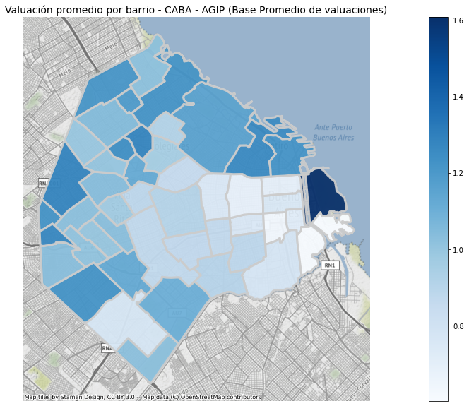

## Properati

La tabla Properati consta de 183810 registros y 25 columnas.

Luego de eliminar los registros que poseen valores nulos en precio y barrio, quedan 178470 filas.

Información de la tabla properati:

```
<class 'pandas.core.frame.DataFrame'>
Int64Index: 178470 entries, 0 to 183809
Data columns (total 25 columns):
 #   Column           Non-Null Count   Dtype
---  ------           --------------   -----
 0   id               178470 non-null  object
 1   ad_type          178470 non-null  object
 2   start_date       178470 non-null  object
 3   end_date         178470 non-null  object
 4   created_on       178470 non-null  object
 5   lat              168297 non-null  float64
 6   lon              168297 non-null  float64
 7   l1               178470 non-null  object
 8   l2               178470 non-null  object
 9   l3               178470 non-null  object
```

[output cut: 17 more lines]

Detalles de los valores nulos:

```
id                      0
ad_type                 0
start_date              0
end_date                0
created_on              0
lat                 10173
lon                 10173
l1                      0
l2                      0
l3                      0
l4                 171467
l5                 178470
l6                 178470
rooms               25944
bedrooms            47467
bathrooms           23386
surface_total       59807
surface_covered     61144
price                   0
currency                0
price_period        94004
title                   0
description             0
property_type           0
operation_type          0
dtype: int64
```

### Currency

La columna `currency` contiene valores `USD` y `ARS`. Vamos a convertir todo a pesos, para que sea comparable de manera directa con AGIP (independientemente que para los índices no es necesario)

```
USD    178184
ARS       286
Name: currency, dtype: int64
```

### Barrios

En CABA existen 48 barrios definidos por el Gobierno local. En el presente análisis se toman estas definiciones como las rectoras para las denominaciones de los barrios. El inconveniente se presenta cuando se intenta compatibilizar la lista de barrios de CABA con la presente en la tabla de Properati.

En Properati se utilizan denominaciones que no están dentro de las oficiales, a efecto de puntualizar de una forma mas precisa, y según los usos y costumbres, una vivienda.

Para poder generar valores promedios de las valuaciones por barrio compatibles con la base de AGIP,es necesario utilizar la misma lista de barrios en ambas tablas.

El resultado de barrios presente en la tabla Properati y no reconocidos en la tabla de AGIP es:

```
['CATALINAS',
 'CONGRESO',
 'LAS CANITAS',
 'ABASTO',
 'BARRIO NORTE',
 'TRIBUNALES',
 'PARQUE CENTENARIO',
 'CENTRO / MICROCENTRO',
 'ONCE',
 'VILLA GENERAL MITRE',
 'POMPEYA',
 'NUNEZ']
```

Las diferencias en los barrios entre ambas tablas pueden solucionarse de dos formas:

- Analizar las denominaciones que no son formalmente barrio en CABA, y vincularlo con el barrio al que pertenece de manera cuasi automática. En el caso que pertenezca a mas de un barrio, se puede aplicar un `spatial join` con los campos `lat` y `lon` de la tabla de properati y la capa de Barrios del GCABA
- Hacer `spatial join` para toda la base. Esto trae algunos resultados erroneos porque los campos `lat` y `lon` no está con todos los decimales necesarios.

El `spatial join` consta de cruzar la latitud y longitud de la propiedad de la tabla properati, con la capa del GCABA. En el cruce, la tabla properati se alimenta del barrio que se corresponde `lat` y `lon` de la tabla.

En resumen, la situación de los barrios de la tabla de properati es la siguiente:

| Properati | AGIP | Fuente |
| --- | --- | --- |
| NaN | Se eliminan, sólo 87 registros |  |
| NUNEZ | NUÑEZ |  |
| VILLA GENERAL MITRE | VILLA GRAL. MITRE |  |
| ONCE | BALVANERA | https://es.wikipedia.org/wiki/Once_(Buenos_Aires) |
| LAS CANITAS | PALERMO | https://es.wikipedia.org/wiki/Las_Ca%C3%B1itas |
| BARRIO NORTE | **Spatial join**: Retiro, Recoleta | https://es.wikipedia.org/wiki/Barrio_Norte_(Buenos_Aires) |
| POMPEYA | NUEVA POMPEYA | https://en.wikipedia.org/wiki/Nueva_Pompeya |
| CONGRESO | BALVANERA | https://es.wikipedia.org/wiki/Balvanera_(Buenos_Aires) |
| TRIBUNALES | SAN NICOLAS | https://es.wikipedia.org/wiki/Tribunales_(Buenos_Aires) |
| PARQUE CENTENARIO | **Spatial join**:Caballito, en una zona limítrofe con los barrios de Almagro y Villa Crespo. | https://es.wikipedia.org/wiki/Parque_Centenario_(Buenos_Aires) |
| ABASTO | **Spatial join**: Balvanera y Almagro | https://es.wikipedia.org/wiki/Abasto_(Buenos_Aires) |
| CATALINAS | Retiro | https://en.wikipedia.org/wiki/Catalinas_Norte |
| CENTRO / MICROCENTRO | **Spatial join**:San Nicolás y parte de los de Monserrat y Retiro | https://es.wikipedia.org/wiki/Microcentro_(Buenos_Aires) |

El procedimiento arroja como resultado 10200 registros que no se ubicaron en el mapa del GCABA. Gran parte de este número tiene el barrio correctamente defino. Es pasos posteriores, de obtendrá el número final de registros que no poseen localización

#### Asignación definitiva de barrios

La asignación definitiva de nombres de barrio consta de varias etapas  
Primero, corrección manual:

| Properati | Corrección manual |
| --- | --- |
| NUNEZ | NUÑEZ |
| VILLA GENERAL MITRE | VILLA GRAL. MITRE |
| ONCE | BALVANERA |
| LAS CANITAS | PALERMO |
| POMPEYA | NUEVA POMPEYA |
| CONGRESO | BALVANERA |
| TRIBUNALES | SAN NICOLAS |
| CATALINAS | RETIRO |

Los barrios que no se ajustaron en el paso anterior, fueron imputados con un `spatial join` con la capa del GCABA.

Como se explicó previamente, el `spatial join` puede traer información erronea por la poca calidad del dato de `lat` y `lon`.

El barrio obtenido del `spatial join` fue contrastado con los barrios que, segun wikipedia, corresponderían a al denominación que utiliza properati. En caso de no corresponderse con ese criterio, ese registro es eliminado.

### Valuación por barrio

Luego de la asignación final de barrios, la tabla queda con 172248 registros con el barrio correctamente definido

Se realiza el mismo procedimiento que se utilizó con la tabla AGIP. Se asignan percentiles a cada uno de los registros, y, en este caso, se eliminan aquellos registros ubicados en el primer y último percentil.

Los valores de Properati son menos propensos a tener distorsiones, ya que son valores publicados para operaciones inmobiliarias. Sólo se elimina *outliers* puntuales de viviendas con características excepcionales.

| barrios_def | count | mean | std | min | 25% | 50% | 75% | max | Coef_Var | Rango_medio |
| --- | --- | --- | --- | --- | --- | --- | --- | --- | --- | --- |
| SAN CRISTOBAL | 3346.00 | 13674098.12 | 13836966.84 | 2056397.18 | 7039193.85 | 9469462.73 | 14700993.07 | 128531250.00 | 1.01 | 9.25 |
| VILLA LUGANO | 1197.00 | 14123882.74 | 11490118.53 | 2570625.00 | 6683522.17 | 10282500.00 | 17994375.00 | 96655500.00 | 0.81 | 6.66 |
| VILLA GRAL. MITRE | 726.00 | 16219456.45 | 11351045.06 | 2364975.00 | 8740125.00 | 12133350.00 | 20050875.00 | 66836250.00 | 0.70 | 3.97 |
| VELEZ SARSFIELD | 479.00 | 16518932.64 | 14325099.68 | 4113000.00 | 8740125.00 | 12544650.00 | 20487881.25 | 215932500.00 | 0.87 | 12.82 |
| BOEDO | 2364.00 | 16567935.06 | 14731548.66 | 1953675.00 | 8215717.50 | 12133350.00 | 18508500.00 | 118248750.00 | 0.89 | 7.02 |
| MONTE CASTRO | 719.00 | 17124940.14 | 10196374.85 | 2570625.00 | 10071708.75 | 13881375.00 | 20462175.00 | 60666750.00 | 0.60 | 3.39 |
| FLORESTA | 2386.00 | 17196217.57 | 13564870.94 | 2117166.75 | 8740125.00 | 12840271.88 | 20565000.00 | 123390000.00 | 0.79 | 7.05 |
| BOCA | 708.00 | 17325888.18 | 32808097.06 | 4113000.00 | 6683625.00 | 9254250.00 | 14909625.00 | 359887500.00 | 1.89 | 20.53 |
| VILLA LURO | 1605.00 | 17396252.61 | 12103545.84 | 3290400.00 | 9459900.00 | 13367250.00 | 20873475.00 | 82260000.00 | 0.70 | 4.54 |
| BALVANERA | 6936.00 | 17468859.73 | 21740758.90 | 1182487.50 | 7197750.00 | 11310750.00 | 17994375.00 | 164520000.00 | 1.24 | 9.35 |
| VILLA SANTA RITA | 665.00 | 17843345.64 | 11806633.05 | 2981925.00 | 9768375.00 | 13881375.00 | 21798900.00 | 77118750.00 | 0.66 | 4.15 |
| SAN TELMO | 2656.00 | 17856442.97 | 19649530.99 | 1953675.00 | 8226000.00 | 11888523.68 | 17994375.00 | 159378750.00 | 1.10 | 8.82 |
| ALMAGRO | 8097.00 | 17868151.16 | 16806357.96 | 1953675.00 | 9254250.00 | 13315837.50 | 19536750.00 | 169661250.00 | 0.94 | 9.39 |
| VILLA RIACHUELO | 43.00 | 18240413.70 | 10042467.83 | 4627125.00 | 11207925.00 | 15937875.00 | 26734500.00 | 39073500.00 | 0.55 | 1.89 |
| VILLA DEL PARQUE | 2597.00 | 18386255.61 | 13122427.36 | 2046217.50 | 10076850.00 | 14292675.00 | 22107375.00 | 97683750.00 | 0.71 | 5.20 |
| PARQUE CHAS | 408.00 | 18754976.82 | 11460797.99 | 5227108.88 | 9845493.75 | 15526575.00 | 22621500.00 | 66733425.00 | 0.61 | 3.28 |
| VILLA PUEYRREDON | 1649.00 | 18782166.46 | 11653653.36 | 1933110.00 | 11300467.50 | 15423750.00 | 23135625.00 | 80203500.00 | 0.62 | 4.17 |
| PARQUE CHACABUCO | 1740.00 | 18879486.63 | 14494979.12 | 2868817.50 | 10132812.51 | 14909625.00 | 21593250.00 | 74034000.00 | 0.77 | 3.77 |
| VILLA REAL | 230.00 | 19035150.43 | 9083399.42 | 6570517.50 | 12339000.00 | 16966125.00 | 22595793.75 | 51412500.00 | 0.48 | 2.36 |
| FLORES | 4994.00 | 19457136.81 | 17177993.08 | 1696612.50 | 9254250.00 | 13881375.00 | 22621500.00 | 149096250.00 | 0.88 | 7.58 |
| NUEVA POMPEYA | 542.00 | 19457923.44 | 19386084.28 | 3598875.00 | 8945775.00 | 14344087.50 | 20539293.75 | 154237500.00 | 1.00 | 7.74 |
| PATERNAL | 1109.00 | 19463525.80 | 19769187.57 | 3598875.00 | 8904645.00 | 13264425.00 | 23649750.00 | 174802500.00 | 1.02 | 8.80 |
| AGRONOMIA | 361.00 | 19545907.41 | 16011238.87 | 3084750.00 | 10231087.50 | 15423750.00 | 22107375.00 | 107966250.00 | 0.82 | 5.37 |
| MATADEROS | 2202.00 | 19884087.90 | 16713786.85 | 3598875.00 | 9279956.25 | 14909625.00 | 23649750.00 | 133672500.00 | 0.84 | 6.54 |
| VILLA URQUIZA | 8089.00 | 19918719.49 | 13529609.61 | 1953675.00 | 11619225.00 | 15927592.50 | 23546925.00 | 102722175.00 | 0.68 | 5.06 |
| LINIERS | 2010.00 | 20016817.77 | 16305755.46 | 2647743.75 | 9768375.00 | 14035612.50 | 25706250.00 | 85344750.00 | 0.81 | 4.13 |
| VERSALLES | 450.00 | 20361738.97 | 11910479.42 | 5655375.00 | 11901993.75 | 16960983.75 | 26091843.75 | 58610250.00 | 0.58 | 2.60 |
| CABALLITO | 10697.00 | 20568350.31 | 15455658.10 | 2313562.50 | 11110344.08 | 15937875.00 | 24678000.00 | 128531250.00 | 0.75 | 6.14 |
| PARQUE AVELLANEDA | 613.00 | 20855073.69 | 14717157.68 | 4627125.00 | 10231087.50 | 16246350.00 | 26734500.00 | 90486000.00 | 0.71 | 4.12 |
| CONSTITUCION | 1064.00 | 20907301.14 | 34881546.97 | 1645200.00 | 7094925.00 | 9768375.00 | 18508500.00 | 277627500.00 | 1.67 | 13.20 |
| VILLA CRESPO | 7688.00 | 20915719.28 | 22333585.31 | 2313562.50 | 9768375.00 | 13881375.00 | 22004550.00 | 199994625.00 | 1.07 | 9.45 |
| COLEGIALES | 3685.00 | 21238546.61 | 16508478.67 | 2981925.00 | 10231087.50 | 15845332.50 | 26734500.00 | 128531250.00 | 0.78 | 5.91 |
| SAAVEDRA | 3032.00 | 21808214.31 | 15187522.68 | 2740080.60 | 11824875.00 | 17063808.75 | 26528850.00 | 133672500.00 | 0.70 | 6.00 |
| COGHLAN | 1639.00 | 22473871.34 | 22019273.19 | 5963850.00 | 12195045.00 | 14909625.00 | 24883650.00 | 246780000.00 | 0.98 | 10.72 |
| MONSERRAT | 2278.00 | 22715100.00 | 34055580.04 | 1336725.00 | 7917525.00 | 12133350.00 | 20565000.00 | 306624150.00 | 1.50 | 13.44 |
| VILLA ORTUZAR | 967.00 | 23088881.63 | 20970855.71 | 2570625.00 | 10076850.00 | 15937875.00 | 26528850.00 | 143852175.00 | 0.91 | 6.12 |
| VILLA SOLDATI | 163.00 | 23914808.88 | 31862161.47 | 2879100.00 | 6940687.50 | 15423750.00 | 25706250.00 | 203593500.00 | 1.33 | 8.39 |
| SAN NICOLAS | 4983.00 | 24431640.42 | 44902125.78 | 1067117.85 | 7197750.00 | 12339000.00 | 22621500.00 | 442147500.00 | 1.84 | 18.05 |
| CHACARITA | 1245.00 | 24489014.42 | 28979627.82 | 2262150.00 | 9768375.00 | 14395500.00 | 25603425.00 | 205650000.00 | 1.18 | 8.31 |
| BARRACAS | 2161.00 | 24699397.59 | 31682332.45 | 2622037.50 | 11053687.50 | 16966125.00 | 25706250.00 | 359887500.00 | 1.28 | 14.46 |
| VILLA DEVOTO | 3111.00 | 25471091.87 | 21486690.58 | 3125880.00 | 12339000.00 | 17994375.00 | 30333375.00 | 152181000.00 | 0.84 | 5.85 |
| NUÑEZ | 4890.00 | 30120020.88 | 30658787.92 | 5614245.00 | 13367250.00 | 20050875.00 | 35860141.63 | 251921250.00 | 1.02 | 8.18 |
| BELGRANO | 20574.00 | 31757938.08 | 30627774.65 | 2035935.00 | 12853125.00 | 21593250.00 | 39073500.00 | 225186750.00 | 0.96 | 7.03 |
| PARQUE PATRICIOS | 1250.00 | 32392771.46 | 55055477.97 | 2827687.50 | 9254250.00 | 14909625.00 | 26605968.75 | 462712500.00 | 1.70 | 14.20 |
| RECOLETA | 9905.00 | 33014066.97 | 33179347.91 | 1902262.50 | 12339000.00 | 22929975.00 | 40101750.00 | 256034250.00 | 1.01 | 7.70 |
| PALERMO | 24573.00 | 33738805.95 | 39480360.59 | 2724862.50 | 12853125.00 | 20127890.93 | 35988750.00 | 287910000.00 | 1.17 | 8.45 |
| RETIRO | 2650.00 | 40672928.01 | 75350584.16 | 1593787.50 | 9759891.94 | 18508500.00 | 40615875.00 | 719775000.00 | 1.85 | 17.66 |
| PUERTO MADERO | 2906.00 | 89805314.03 | 65283241.48 | 8328825.00 | 42158250.00 | 68892750.00 | 123390000.00 | 390735000.00 | 0.73 | 4.26 |

|  | barrios_def | price | index_properati |
| --- | --- | --- | --- |
| 26 | PUERTO MADERO | 873057.64 | 392.24% |
| 28 | RETIRO | 396563.93 | 178.16% |
| 20 | PALERMO | 328853.76 | 147.74% |
| 27 | RECOLETA | 321593.68 | 144.48% |
| 24 | PARQUE PATRICIOS | 315028.17 | 141.53% |
| 4 | BELGRANO | 309191.32 | 138.91% |
| 19 | NUÑEZ | 293132.38 | 131.70% |
| 37 | VILLA DEVOTO | 248518.69 | 111.65% |
| 3 | BARRACAS | 241880.64 | 108.67% |
| 8 | CHACARITA | 239295.16 | 107.51% |
| 31 | SAN NICOLAS | 238825.65 | 107.30% |
| 46 | VILLA SOLDATI | 232577.77 | 104.49% |
| 41 | VILLA ORTUZAR | 224545.41 | 100.88% |
| 16 | MONSERRAT | 223037.05 | 100.20% |
| 9 | COGHLAN | 218772.47 | 98.29% |
| 29 | SAAVEDRA | 212356.18 | 95.41% |
| 11 | CONSTITUCION | 207302.74 | 93.14% |
| 10 | COLEGIALES | 206597.47 | 92.82% |
| 35 | VILLA CRESPO | 203869.72 | 91.59% |
| 21 | PARQUE AVELLANEDA | 203673.66 | 91.50% |
| 7 | CABALLITO | 200255.31 | 89.97% |
| 34 | VERSALLES | 198023.23 | 88.97% |
| 14 | LINIERS | 194668.78 | 87.46% |
| 47 | VILLA URQUIZA | 194032.95 | 87.17% |
| 15 | MATADEROS | 193471.74 | 86.92% |
| 0 | AGRONOMIA | 190089.06 | 85.40% |
| 25 | PATERNAL | 189991.23 | 85.36% |
| 12 | FLORES | 189516.28 | 85.14% |
| 18 | NUEVA POMPEYA | 189233.39 | 85.02% |
| 43 | VILLA REAL | 185121.81 | 83.17% |
| 22 | PARQUE CHACABUCO | 183607.94 | 82.49% |
| 23 | PARQUE CHAS | 183051.34 | 82.24% |
| 42 | VILLA PUEYRREDON | 182939.90 | 82.19% |
| 36 | VILLA DEL PARQUE | 178934.77 | 80.39% |
| 44 | VILLA RIACHUELO | 177392.79 | 79.70% |
| 1 | ALMAGRO | 174058.08 | 78.20% |
| 32 | SAN TELMO | 173979.00 | 78.16% |
| 45 | VILLA SANTA RITA | 173531.20 | 77.96% |
| 2 | BALVANERA | 170587.71 | 76.64% |
| 5 | BOCA | 169389.48 | 76.10% |
| 40 | VILLA LURO | 169183.10 | 76.01% |
| 13 | FLORESTA | 167237.71 | 75.14% |
| 17 | MONTE CASTRO | 166544.52 | 74.82% |
| 6 | BOEDO | 161127.50 | 72.39% |
| 33 | VELEZ SARSFIELD | 160650.94 | 72.18% |
| 38 | VILLA GRAL. MITRE | 157738.45 | 70.87% |
| 39 | VILLA LUGANO | 137953.31 | 61.98% |
| 30 | SAN CRISTOBAL | 132984.18 | 59.75% |

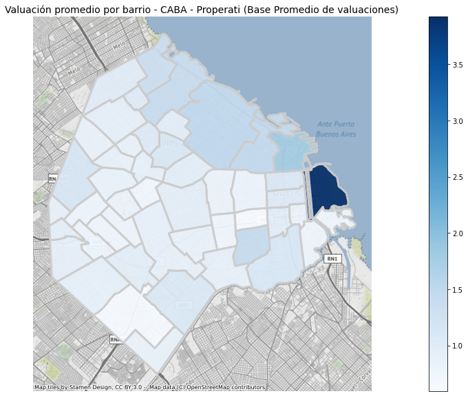

## Análisis combinado

#### Histograma Total CABA (Properati - AGIP)

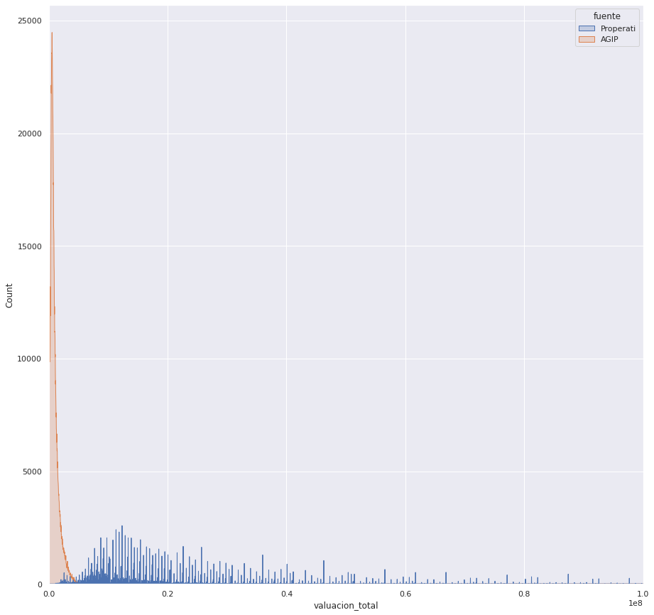

#### Histograma Barrios CABA (Properati - AGIP)

El gráfico a continuación muestra la distribución de los precios de AGIP y Properati para cada uno de los 48 barrios.

Para cada uno los barrios, la tabla de AGIP posee una cantidad mayor de registros, **con valuaciones sustancialmente menores que las de Properati.**

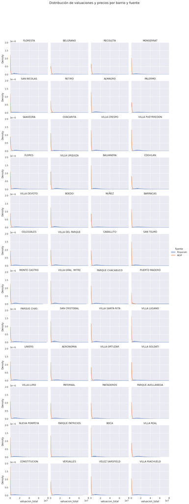

#### BarPlot: Barrios y valuaciones promedios, según fuente de información

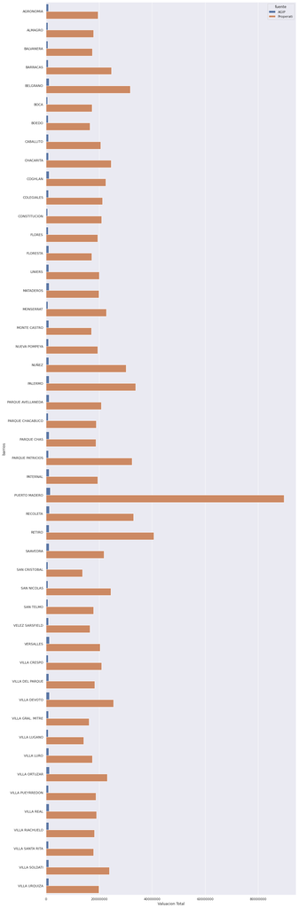

### Índice combinado

A continuación se presenta el índice combinado, que es el cociente entre el *Indice Properati* y el *Indice Agip*

$$Indice_{combinado} = \frac{Indice_{Properati}}{Indice_{AGIP}}$$

|  | barrios | IVP | index_ratio | index_properati | index_agip |
| --- | --- | --- | --- | --- | --- |
| 40 | PUERTO MADERO | 144.01 | 2.44 | 3.92 | 1.61 |
| 16 | PARQUE PATRICIOS | 60.00 | 1.60 | 1.42 | 0.88 |
| 42 | SAN NICOLAS | 53.89 | 1.54 | 1.07 | 0.70 |
| 11 | CONSTITUCION | 46.12 | 1.46 | 0.93 | 0.64 |
| 45 | RETIRO | 45.42 | 1.45 | 1.78 | 1.23 |
| 29 | BARRACAS | 39.49 | 1.39 | 1.09 | 0.78 |
| 41 | MONSERRAT | 32.49 | 1.32 | 1.00 | 0.76 |
| 46 | NUÑEZ | 29.01 | 1.29 | 1.32 | 1.02 |
| 33 | PALERMO | 27.54 | 1.28 | 1.48 | 1.16 |
| 47 | BOCA | 26.06 | 1.26 | 0.76 | 0.60 |
| 44 | RECOLETA | 14.49 | 1.14 | 1.44 | 1.26 |
| 43 | BELGRANO | 13.74 | 1.14 | 1.39 | 1.22 |
| 0 | CHACARITA | 12.43 | 1.12 | 1.08 | 0.96 |
| 24 | BALVANERA | 11.47 | 1.11 | 0.77 | 0.69 |
| 19 | SAN TELMO | 8.79 | 1.09 | 0.78 | 0.72 |
| 2 | VILLA CRESPO | 6.88 | 1.07 | 0.92 | 0.86 |
| 4 | ALMAGRO | 4.24 | 1.04 | 0.78 | 0.75 |
| 23 | COLEGIALES | 1.39 | 1.01 | 0.93 | 0.92 |
| 5 | CABALLITO | -0.96 | 0.99 | 0.90 | 0.91 |
| 9 | FLORES | -2.35 | 0.98 | 0.85 | 0.87 |
| 35 | VILLA SOLDATI | -4.98 | 0.95 | 1.04 | 1.10 |
| 31 | PARQUE CHACABUCO | -5.21 | 0.95 | 0.82 | 0.87 |
| 32 | NUEVA POMPEYA | -5.78 | 0.94 | 0.85 | 0.90 |
| 37 | VILLA DEVOTO | -12.71 | 0.87 | 1.12 | 1.28 |
| 27 | AGRONOMIA | -14.64 | 0.85 | 0.85 | 1.00 |
| 38 | LINIERS | -15.21 | 0.85 | 0.87 | 1.03 |
| 13 | BOEDO | -16.43 | 0.84 | 0.72 | 0.87 |
| 22 | VILLA URQUIZA | -16.58 | 0.83 | 0.87 | 1.05 |
| 36 | VILLA PUEYRREDON | -17.33 | 0.83 | 0.82 | 0.99 |
| 21 | COGHLAN | -17.42 | 0.83 | 0.98 | 1.19 |
| 30 | PARQUE AVELLANEDA | -18.56 | 0.81 | 0.92 | 1.12 |
| 18 | VILLA LUGANO | -19.63 | 0.80 | 0.62 | 0.77 |
| 6 | VILLA SANTA RITA | -19.72 | 0.80 | 0.78 | 0.97 |
| 25 | VILLA GRAL. MITRE | -19.96 | 0.80 | 0.71 | 0.89 |
| 28 | VILLA ORTUZAR | -21.10 | 0.79 | 1.01 | 1.28 |
| 12 | SAN CRISTOBAL | -21.32 | 0.79 | 0.60 | 0.76 |
| 20 | SAAVEDRA | -21.42 | 0.79 | 0.95 | 1.21 |
| 34 | VILLA RIACHUELO | -22.36 | 0.78 | 0.80 | 1.03 |
| 3 | VILLA DEL PARQUE | -22.41 | 0.78 | 0.80 | 1.04 |
| 1 | PATERNAL | -24.13 | 0.76 | 0.85 | 1.13 |
| 15 | VILLA LURO | -25.00 | 0.75 | 0.76 | 1.01 |
| 7 | MONTE CASTRO | -26.99 | 0.73 | 0.75 | 1.02 |
| 10 | FLORESTA | -27.01 | 0.73 | 0.75 | 1.03 |
| 14 | VELEZ SARSFIELD | -27.80 | 0.72 | 0.72 | 1.00 |
| 17 | MATADEROS | -28.75 | 0.71 | 0.87 | 1.22 |
| 39 | VERSALLES | -29.82 | 0.70 | 0.89 | 1.27 |
| 8 | VILLA REAL | -31.86 | 0.68 | 0.83 | 1.22 |
| 26 | PARQUE CHAS | -33.45 | 0.67 | 0.82 | 1.24 |

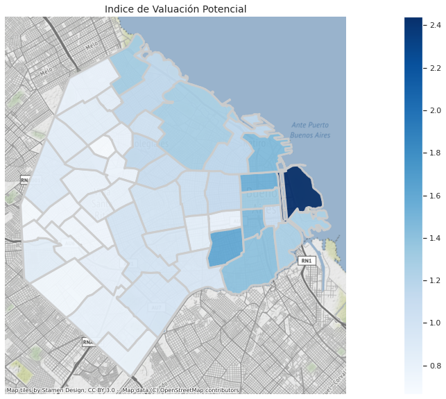

[figure not shown]

#### BarPlot Indices AGIP y Properati por barrio

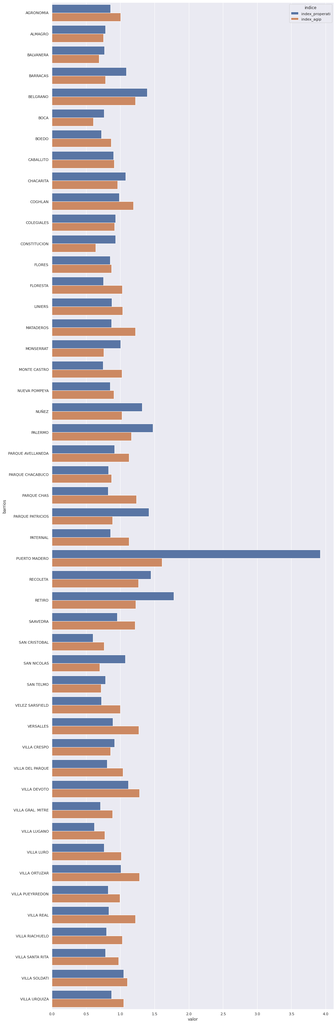

[output not shown]